# Lab 10

Makesh Srinivasan

11/9/2021

## Healthcare analytics

Instructions: Analyze any healthcare related data set of your choice for handling missing values, performing data manipulation, statistical analysis, basic visualization, correlation & Regression analysis with proper inferences. Provide your submission in html format. {Do whatever analysis is applicable]

For this exercise, I plan to do the following. 1) Data manipulation 2) Data cleaning 3) Visualisation and plotting 4) Regression analysis

NOTE: all the previous exercises (8 in total) are incorporated into these four topics.

#### 1) Data manipulation

1.1) Import the dataset “insurance.csv”

```r
data <- read.csv("insurance.csv")
head(data)
```

```
##   age    sex    bmi children smoker    region   charges
## 1  19 female 27.900        0    yes southwest 16884.924
## 2  18   male 33.770        1     no southeast  1725.552
## 3  28   male 33.000        3     no southeast  4449.462
## 4  33   male 22.705        0     no northwest 21984.471
## 5  32   male 28.880        0     no northwest  3866.855
## 6  31 female 25.740        0     no southeast  3756.622
```

1.2) Explore the structure of the dataset and print the dimension of the same

```r
str(data)
```

```
## 'data.frame':    1338 obs. of  7 variables:
##  $ age     : int  19 18 28 33 32 31 46 37 37 60 ...
##  $ sex     : chr  "female" "male" "male" "male" ...
##  $ bmi     : num  27.9 33.8 33 22.7 28.9 ...
##  $ children: int  0 1 3 0 0 0 1 3 2 0 ...
##  $ smoker  : chr  "yes" "no" "no" "no" ...
##  $ region  : chr  "southwest" "southeast" "southeast" "northwest" ...
##  $ charges : num  16885 1726 4449 21984 3867 ...
```

```r
print("Dimension: ")
```

```
## [1] "Dimension: "
```

```r
dim(data)
```

```
## [1] 1338    7
```

We can see that the datatypes of sex, smoker and region are chr, while others are int or num. For regression analysis (step-4), we need to convert the chr datatype to numeric datatype. This conversion is generally done in data cleaning stage, but can also be done in the data manipulation step.

1.3) Convert chr to numberic types

```r
unique(data["sex"])
```

```
##      sex
## 1 female
## 2   male
```

```r
unique(data["region"])
```

```
##      region
## 1 southwest
## 2 southeast
## 4 northwest
## 9 northeast
```

```r
unique(data["smoker"])
```

```
##   smoker
## 1    yes
## 2     no
```

```r
data[data$sex=="male", 'sex'] <- as.numeric(1)
data[data$sex=="female", 'sex'] <- as.numeric(2)

data[data$smoker=="yes", 'smoker'] <- as.numeric(1)
data[data$smoker=="no", 'smoker'] <- as.numeric(0)

data[data$region=="southwest", 'region'] <- as.numeric(1)
data[data$region=="southeast", 'region'] <- as.numeric(2)
data[data$region=="northwest", 'region'] <- as.numeric(3)
data[data$region=="northeast", 'region'] <- as.numeric(4)

data$sex = as.numeric(as.character(data$sex))
data$region = as.numeric(as.character(data$region))
data$smoker = as.numeric(as.character(data$smoker))
head(data, 7)
```

```
##   age sex    bmi children smoker region   charges
## 1  19   2 27.900        0      1      1 16884.924
## 2  18   1 33.770        1      0      2  1725.552
## 3  28   1 33.000        3      0      2  4449.462
## 4  33   1 22.705        0      0      3 21984.471
## 5  32   1 28.880        0      0      3  3866.855
## 6  31   2 25.740        0      0      2  3756.622
## 7  46   2 33.440        1      0      2  8240.590
```

```r
str(data)
```

```
## 'data.frame':    1338 obs. of  7 variables:
##  $ age     : int  19 18 28 33 32 31 46 37 37 60 ...
##  $ sex     : num  2 1 1 1 1 2 2 2 1 2 ...
##  $ bmi     : num  27.9 33.8 33 22.7 28.9 ...
##  $ children: int  0 1 3 0 0 0 1 3 2 0 ...
##  $ smoker  : num  1 0 0 0 0 0 0 0 0 0 ...
##  $ region  : num  1 2 2 3 3 2 2 3 4 3 ...
##  $ charges : num  16885 1726 4449 21984 3867 ...
```

Now, all the datatypes are numeric or int. We can proceed to the next step

#### 2) Data cleaning

```r
library(tidyverse)
```

2.1) Check for NA values in the dataset

```r
print(paste("Number of missing values = ", sum(is.na(data))))
```

```
## [1] "Number of missing values =  0"
```

2.2) Check for duplicate entries:

```r
print(paste("Number of duplicate entries = ", sum(duplicated(data)) - 1))
```

```
## [1] "Number of duplicate entries =  0"
```

```r
summary(data)
```

```
##       age             sex             bmi           children
##  Min.   :18.00   Min.   :1.000   Min.   :15.96   Min.   :0.000
##  1st Qu.:27.00   1st Qu.:1.000   1st Qu.:26.30   1st Qu.:0.000
##  Median :39.00   Median :1.000   Median :30.40   Median :1.000
##  Mean   :39.21   Mean   :1.495   Mean   :30.66   Mean   :1.095
##  3rd Qu.:51.00   3rd Qu.:2.000   3rd Qu.:34.69   3rd Qu.:2.000
##  Max.   :64.00   Max.   :2.000   Max.   :53.13   Max.   :5.000
##      smoker           region         charges
##  Min.   :0.0000   Min.   :1.000   Min.   : 1122
##  1st Qu.:0.0000   1st Qu.:2.000   1st Qu.: 4740
##  Median :0.0000   Median :2.000   Median : 9382
##  Mean   :0.2048   Mean   :2.484   Mean   :13270
##  3rd Qu.:0.0000   3rd Qu.:3.000   3rd Qu.:16640
##  Max.   :1.0000   Max.   :4.000   Max.   :63770
```

#### 3) Data visualisation and plotting

Import the necessary libraries

```r
library(dplyr)
library(caret)
```

```r
library(ggplot2)
```

```r
data%>%
  group_by(sex) %>%
  summarize(Smokers = length(smoker))
```

```
## # A tibble: 2 × 2
##     sex Smokers
##   <dbl>   <int>
## 1     1     676
## 2     2     662
```

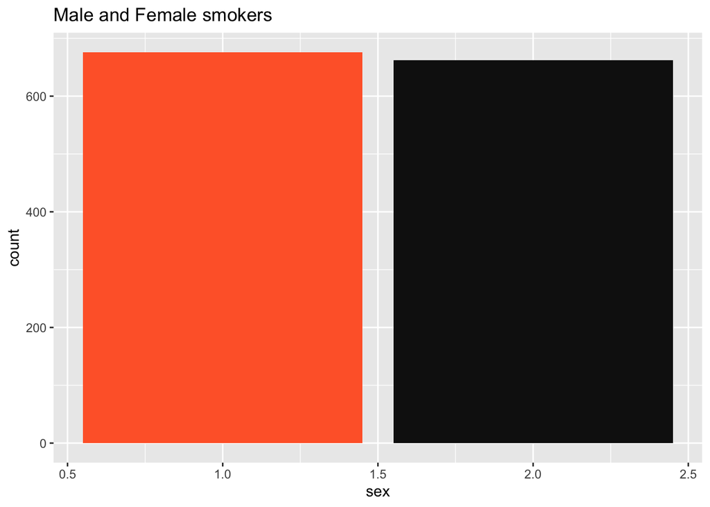

```r
ggplot(data,aes(x=sex))+geom_bar(fill = c("#FF6633","#121212"))+ggtitle("Male and Female smokers")
```

3.3) Show the pie chart of the sokers and non-smokers

[figure not shown]

```r
pie(table(data$smoker), main="Male Left Handers Smoking Habits", col=rainbow(length(unique(data$smoker))), radius=1)
```

Inference: We can see that most of the population is non-smoker which means the charges will be generally lower than the median value. This is because most of the population is healther.

3.4) Age distribution on a histogram plot

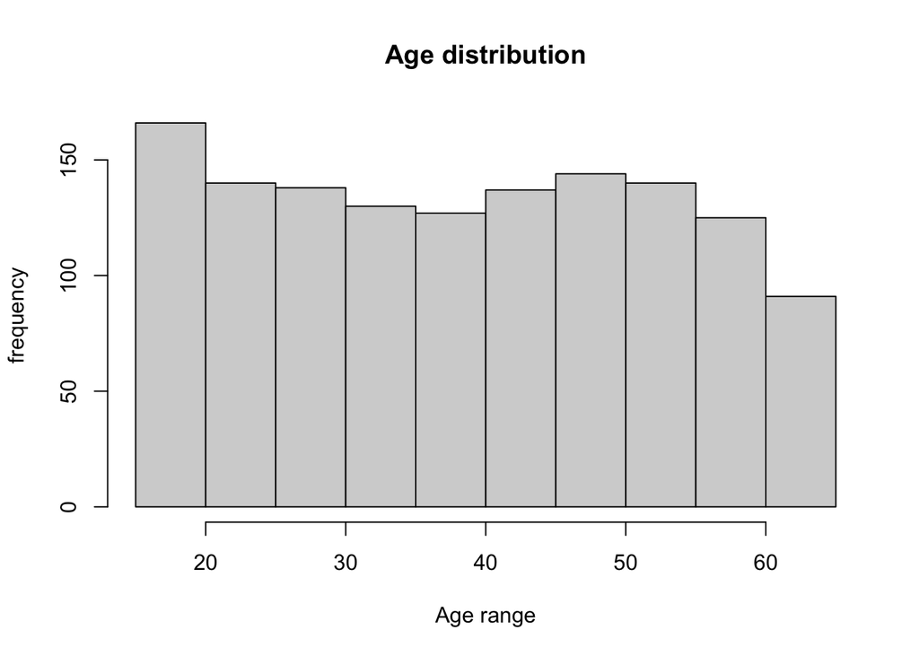

```r
hist(data$age, main = "Age distribution", xlab = "Age range", ylab = "frequency")
```

The majority of the dataset is a representation of younger population - less than age of 40. Hence, we should see some healthier people and as a result, the charges will be lower than the median value in general.

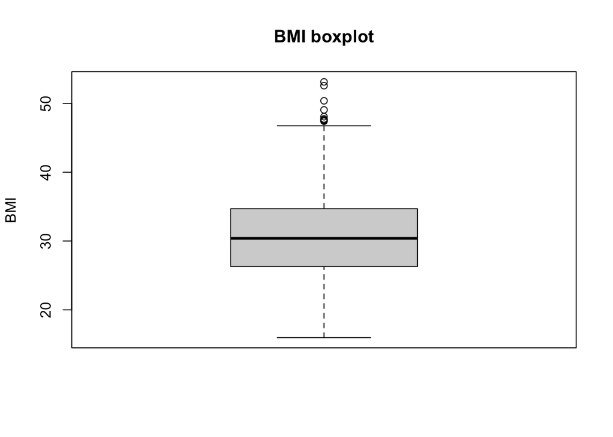

```r
boxplot(data$bmi, main="BMI boxplot", ylab = "BMI")
```

Inference: The distribution is not skewed as the median is right along the center of the box. There are several outliers in this dataset for the BMI indeces. The interquartile range and percentiles are given below. The max and min values are also shown on the image above.

```r
IQR(data$bmi)
```

```
## [1] 8.3975
```

```r
percentile_bmi = quantile(data$bmi, c(.25,.50,.75))
percentile_bmi
```

```
##      25%      50%      75%
## 26.29625 30.40000 34.69375
```

We have explored the individual attributes enough. We can move to correlation, pairplots and relation between variables now.

3.6) Pair plots of the attributes:

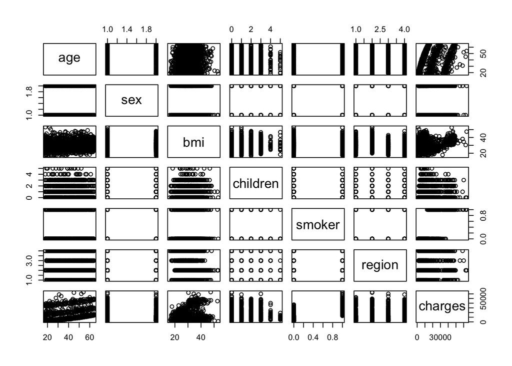

```r
pairs(data[,c("age","sex","bmi","children","smoker","region", "charges")])
```

3.7) Correlation between the features and charges attribute.

```r
cols = colnames(data)
for (c in cols) {
  print(paste("Column", c, ": ", cor(data[[c]],data$charges)))
}
```

```
## [1] "Column age :  0.299008193330648"
## [1] "Column sex :  -0.0572920622020254"
## [1] "Column bmi :  0.198340968833629"
## [1] "Column children :  0.0679982268479048"
## [1] "Column smoker :  0.787251430498477"
## [1] "Column region :  0.00620823490944446"
## [1] "Column charges :  1"
```

3.8) Covariance between the features and charges attribute.

```r
cols = colnames(data)
for (c in cols) {
  print(paste("Column", c, ": ", cov(data[[c]],data$charges)))
}
```

```
## [1] "Column age :  50874.8022978585"
## [1] "Column sex :  -347.014468888939"
## [1] "Column bmi :  14647.3044263222"
## [1] "Column children :  992.674197051653"
## [1] "Column smoker :  3848.66703155669"
## [1] "Column region :  83.0672309098477"
## [1] "Column charges :  146652372.152855"
```

3.10) Mean, median and std. deviation of the charges attribute.

```r
mean_charge <- mean(data$charges)
median_charge <- median(data$charges)
var_charge <- var(data$charges)
sd_charge <- sd(data$charges)
print(paste("mean_charge = ", mean_charge))
```

```
## [1] "mean_charge =  13270.4222651413"
```

```r
print(paste("median_charge = ", median_charge))
```

```
## [1] "median_charge =  9382.033"
```

```r
print(paste("var_charge = ", var_charge))
```

```
## [1] "var_charge =  146652372.152855"
```

```r
print(paste("sd_charge = ", sd_charge))
```

```
## [1] "sd_charge =  12110.011236694"
```

3.11) Show the scatter plot of the BMI and charges

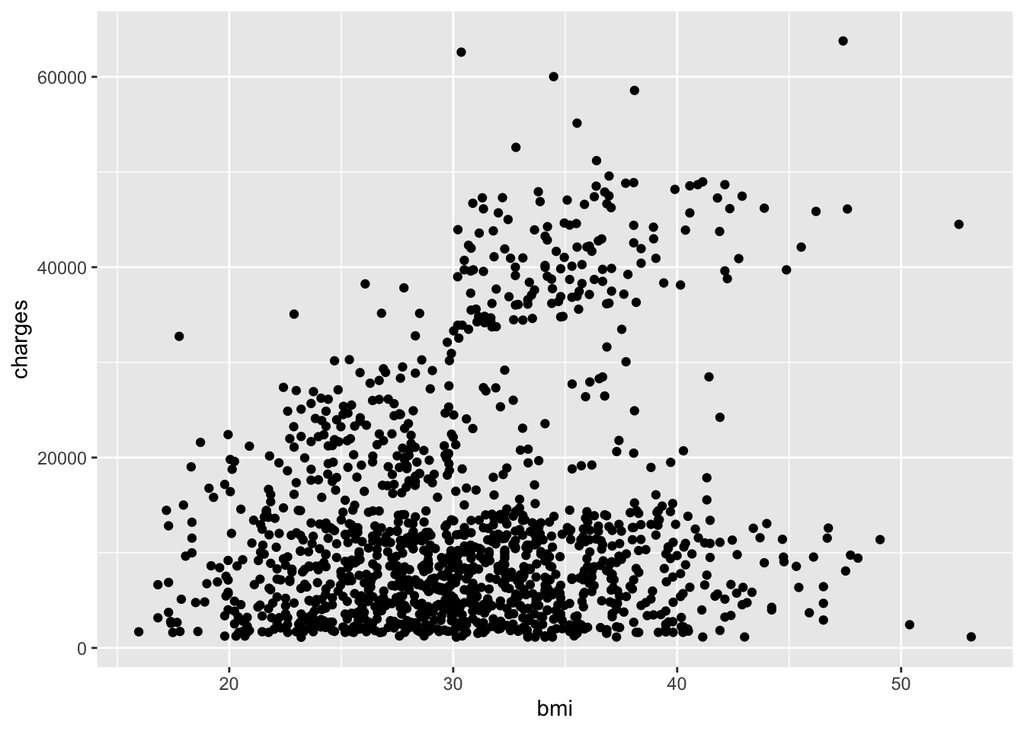

```r
ggplot(data, aes(x=bmi,y=charges))+geom_point()
```

There is not much linearity as shown above - this is supported by the lower value of the correlation coefficient above.

3.12) Show the scatter plot of the smoker and charges

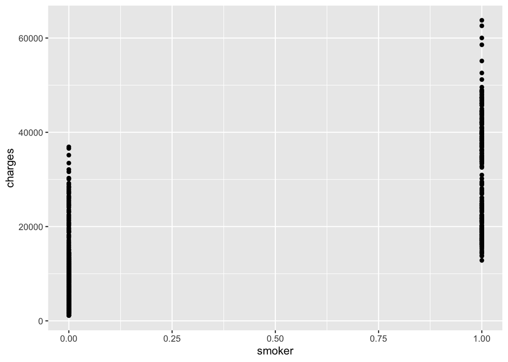

```r
ggplot(data, aes(x=smoker,y=charges))+geom_point()
```

3.13) Show the scatter plot of the age and charges

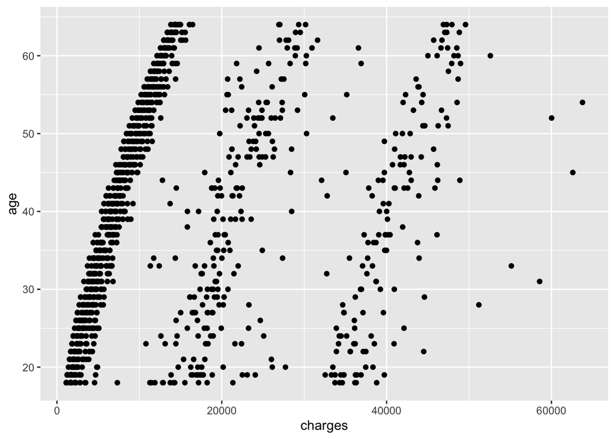

```r
ggplot(data, aes(x=charges,y=age))+geom_point()
```

There is minimal correlation between the age and the carges attribute. But generally, the value of the chrages increases as the age increases as shown above.

We have seen enough plots and analysis between the variables

Step-4 can now begin.

#### 4) Rregression analysis

NOTE: This dataset in its raw format as used now may not yeild a very good linear regression model and thus, we have to explore other techniques such as polynomial regression or logistic regression, etc. ##### Linear model using all attributes 4.1) Model with all columns

```r
model1 <- lm(charges~.,data=data)
model1
```

```
##
## Call:
## lm(formula = charges ~ ., data = data)
##
## Coefficients:
## (Intercept)          age          sex          bmi     children       smoker
##    -13492.2        257.3        131.1        332.6        479.4      23820.4
##      region
##       353.6
```

Generated the linear model. 4.2) Summary of the model

```r
summary(model1)
```

```
##
## Call:
## lm(formula = charges ~ ., data = data)
##
## Residuals:
##    Min     1Q Median     3Q    Max
## -11343  -2807  -1017   1408  29752
##
## Coefficients:
##              Estimate Std. Error t value Pr(>|t|)
## (Intercept) -13492.23    1195.73 -11.284  < 2e-16 ***
## age            257.29      11.89  21.647  < 2e-16 ***
## sex            131.11     332.81   0.394 0.693681
## bmi            332.57      27.72  11.997  < 2e-16 ***
## children       479.37     137.64   3.483 0.000513 ***
## smoker       23820.43     411.84  57.839  < 2e-16 ***
## region         353.64     151.93   2.328 0.020077 *
## ---
## Signif. codes:  0 '***' 0.001 '**' 0.01 '*' 0.05 '.' 0.1 ' ' 1
##
## Residual standard error: 6060 on 1331 degrees of freedom
## Multiple R-squared:  0.7507, Adjusted R-squared:  0.7496
## F-statistic: 668.1 on 6 and 1331 DF,  p-value: < 2.2e-16
```

The r squared and adjusted r squared values are 0.750 and 0.749 respectively. They are virtually similar however, the degrees of freedom is extremely high for this model. There are 5 statistically significant attributes for this model and they are age, bmi, children, and smoker. Even region can be considered significant with one star but sex cannot be considered as such.

4.3) Sigma of the model

```r
sigma(model1)
```

```
## [1] 6059.684
```

4.4) Confidence interval of the model

```r
confint(model1)
```

```
##                    2.5 %      97.5 %
## (Intercept) -15837.94688 -11146.5202
## age            233.97124    280.6049
## sex           -521.78012    784.0013
## bmi            278.18623    386.9540
## children       209.34614    749.3926
## smoker       23012.50222  24628.3660
## region          55.59835    651.6817
```

4.5) Residuals vs Fitted:

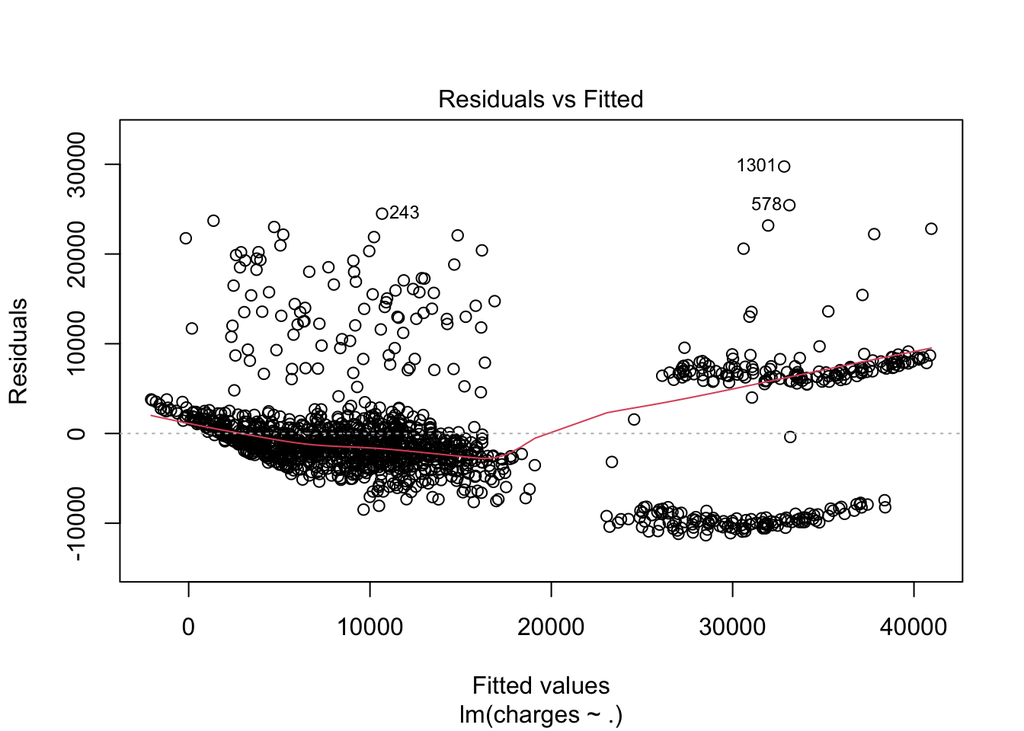

```r
plot(model1, 1)
```

The red line does not coincide well with the residual=0 which indicates that the prediction accuracy is containing high variance compared to the actual values. 4.6) Model1 diagnostics

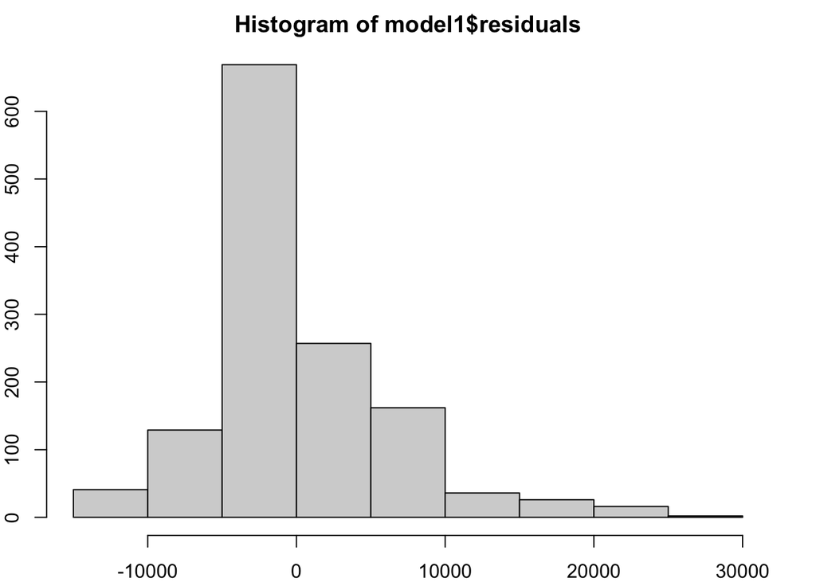

```r
par(mar=c(2,2,2,2))
hist(model1$residuals)
```

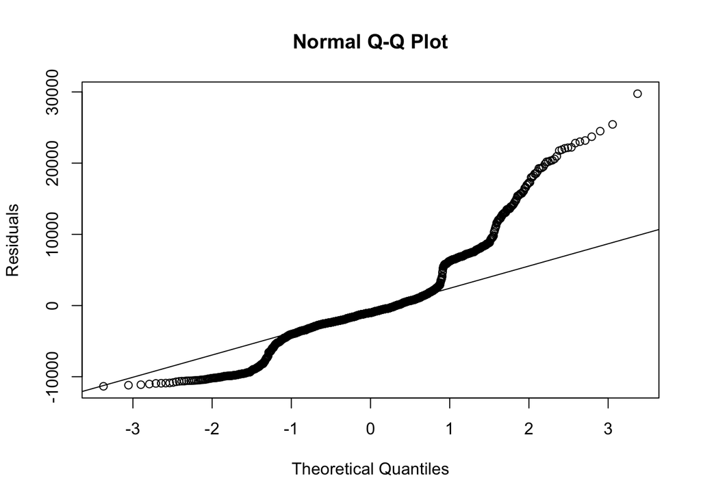

```r
qqnorm(model1$residuals,ylab = "Residuals")
qqline(model1$residuals)
```

Again, the normalised values do not fall on the line indicating that the performance of the model in terms of prediction is not as accurate. {Must lie on the line to be considered accuracte}

##### Linear model using the significant attributes only

Significant attributes = age,bmi,children,smoker,region

```r
data = subset(data, select = c(age,bmi,children,smoker,region,charges))
str(data)
```

```
## 'data.frame':    1338 obs. of  6 variables:
##  $ age     : int  19 18 28 33 32 31 46 37 37 60 ...
##  $ bmi     : num  27.9 33.8 33 22.7 28.9 ...
##  $ children: int  0 1 3 0 0 0 1 3 2 0 ...
##  $ smoker  : num  1 0 0 0 0 0 0 0 0 0 ...
##  $ region  : num  1 2 2 3 3 2 2 3 4 3 ...
##  $ charges : num  16885 1726 4449 21984 3867 ...
```

4.7) Plots of the trend between the significant attributes and the label - charges

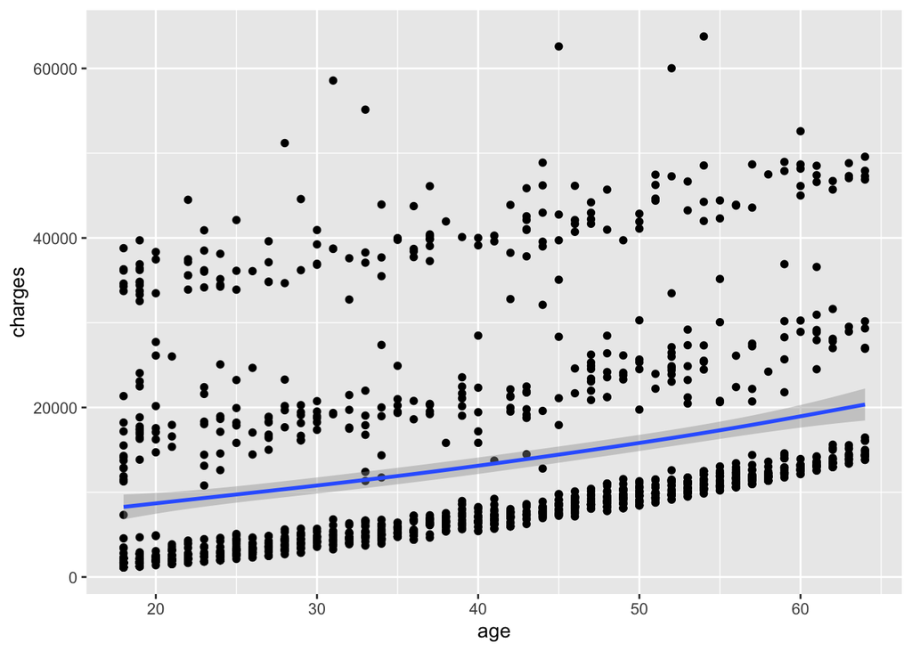

```r
ggplot(data,aes(x=age,y=charges))+geom_point()+geom_smooth()
```

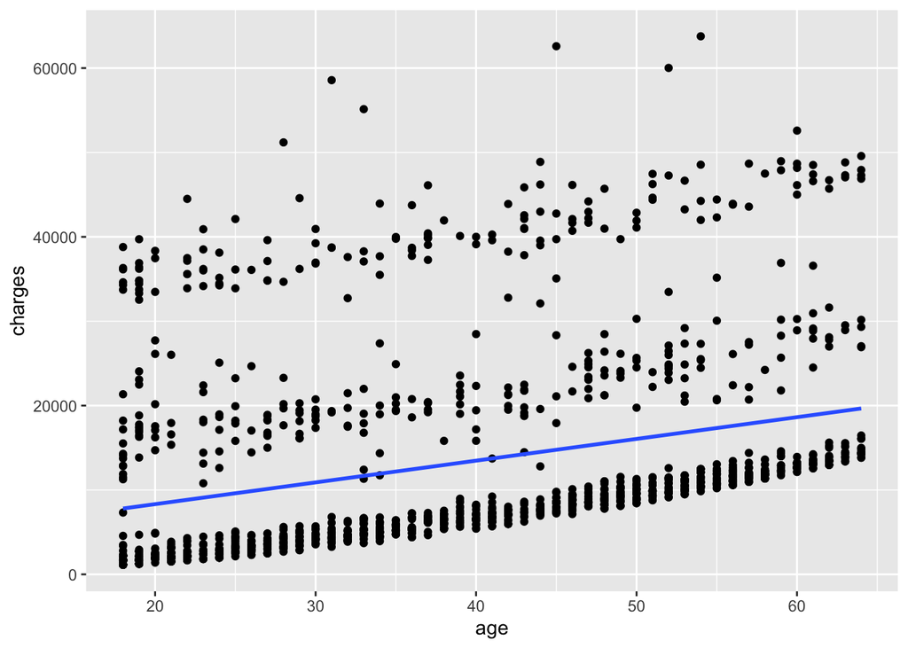

```r
ggplot(data,aes(x=age,y=charges))+geom_point()+geom_smooth(method='lm',se=FALSE)
```

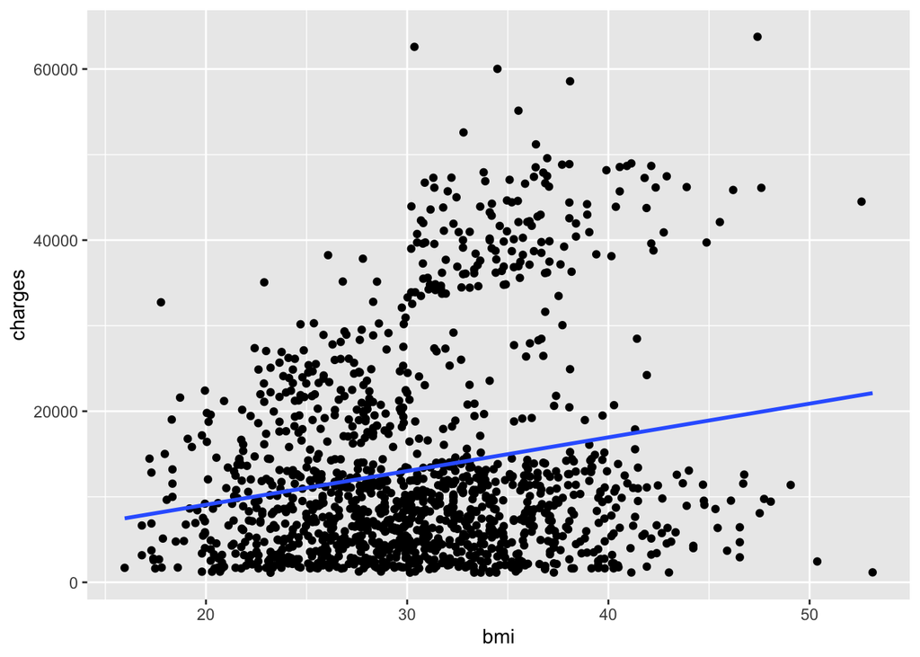

```r
ggplot(data,aes(x=bmi,y=charges))+geom_point()+geom_smooth(method='lm',se=FALSE)
```

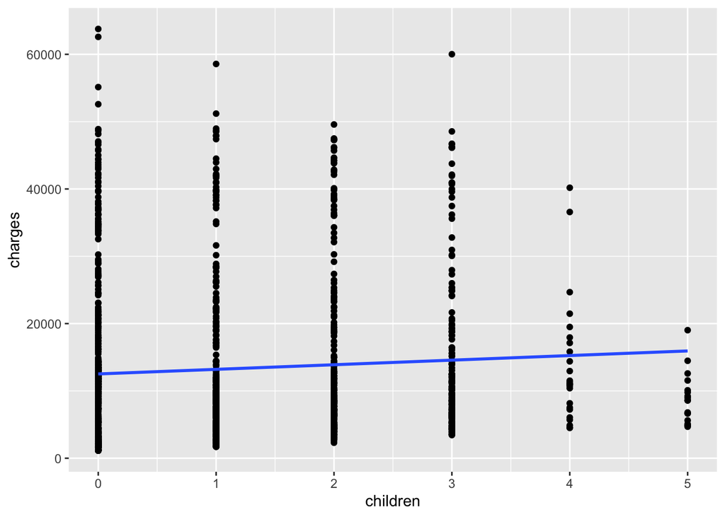

```r
ggplot(data,aes(x=children,y=charges))+geom_point()+geom_smooth(method='lm',se=FALSE)
```

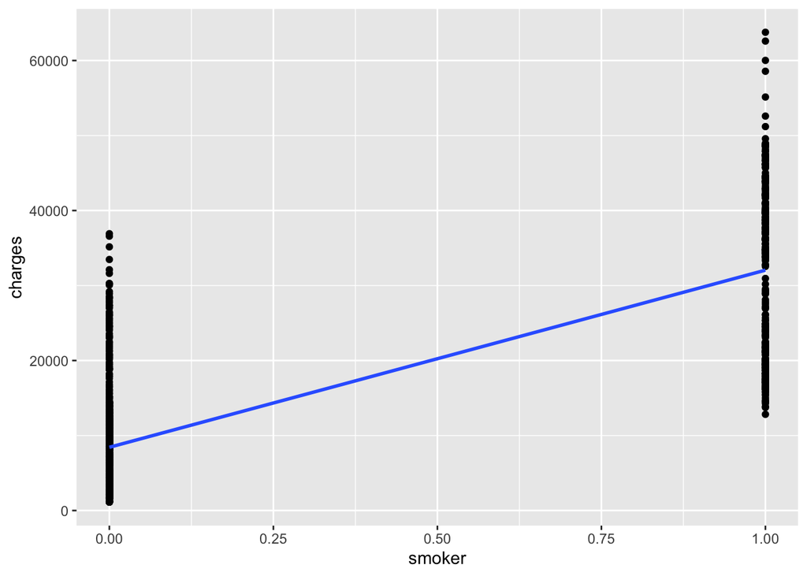

```r
ggplot(data,aes(x=smoker,y=charges))+geom_point()+geom_smooth(method='lm',se=FALSE)
```

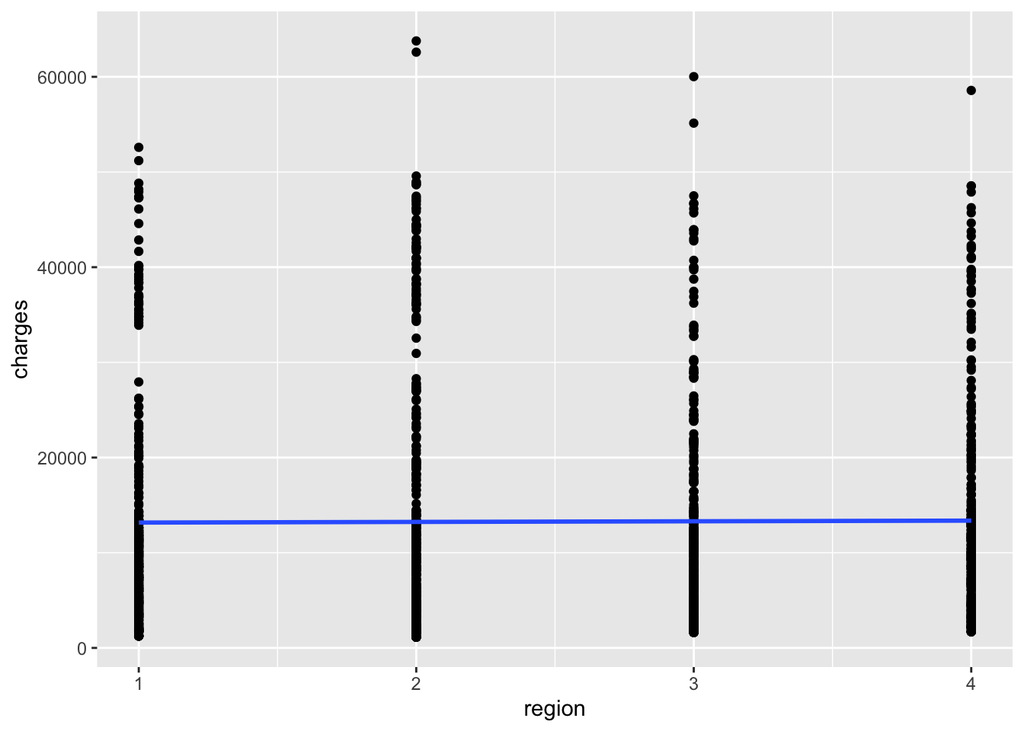

```r
ggplot(data,aes(x=region,y=charges))+geom_point()+geom_smooth(method='lm',se=FALSE)
```

4.8) Linear model building

```r
set.seed(123)
train_samples <- data$charges %>%
  createDataPartition(p=0.8,list=FALSE)
head(train_samples)
```

```
##      Resample1
## [1,]         1
## [2,]         2
## [3,]         3
## [4,]         4
## [5,]         6
## [6,]         7
```

```r
train <- data[train_samples,]
test <- data[-train_samples,]
model2 <- lm(charges~.,data=train)
```

The dataset is split into train and test set and the model is trained - model2

4.9) Summary

```r
summary(model2)
```

```
##
## Call:
## lm(formula = charges ~ ., data = train)
##
## Residuals:
##      Min       1Q   Median       3Q      Max
## -11691.5  -2692.9   -927.5   1383.5  29409.8
##
## Coefficients:
##              Estimate Std. Error t value Pr(>|t|)
## (Intercept) -12714.23    1181.80 -10.758   <2e-16 ***
## age            247.50      13.21  18.743   <2e-16 ***
## bmi            323.56      30.73  10.529   <2e-16 ***
## children       437.96     153.84   2.847   0.0045 **
## smoker       24216.88     452.62  53.504   <2e-16 ***
## region         359.77     169.83   2.118   0.0344 *
## ---
## Signif. codes:  0 '***' 0.001 '**' 0.01 '*' 0.05 '.' 0.1 ' ' 1
##
## Residual standard error: 6003 on 1066 degrees of freedom
## Multiple R-squared:  0.7593, Adjusted R-squared:  0.7582
## F-statistic: 672.5 on 5 and 1066 DF,  p-value: < 2.2e-16
```

The R squared value of the train set is higher than it was in Model1. This is because the insignificant attribute is eliminated and therefore there is less noise in the data.

4.10) Sigma of the model

```r
sigma(model2)
```

```
## [1] 6003.32
```

4.11) Confidence interval of the model

```r
confint(model2)
```

```
##                    2.5 %      97.5 %
## (Intercept) -15033.15052 -10395.3127
## age            221.59022    273.4128
## bmi            263.26093    383.8601
## children       136.08962    739.8244
## smoker       23328.75778  25105.0057
## region          26.53638    693.0006
```

4.12) Residuals vs Fitted:

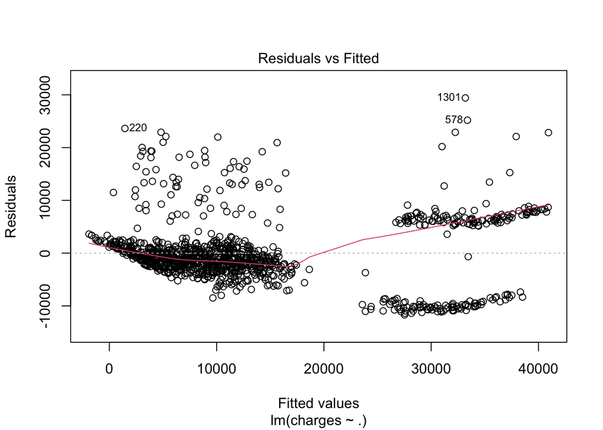

```r
plot(model2, 1)
```

4.13) Model2 diagnostics

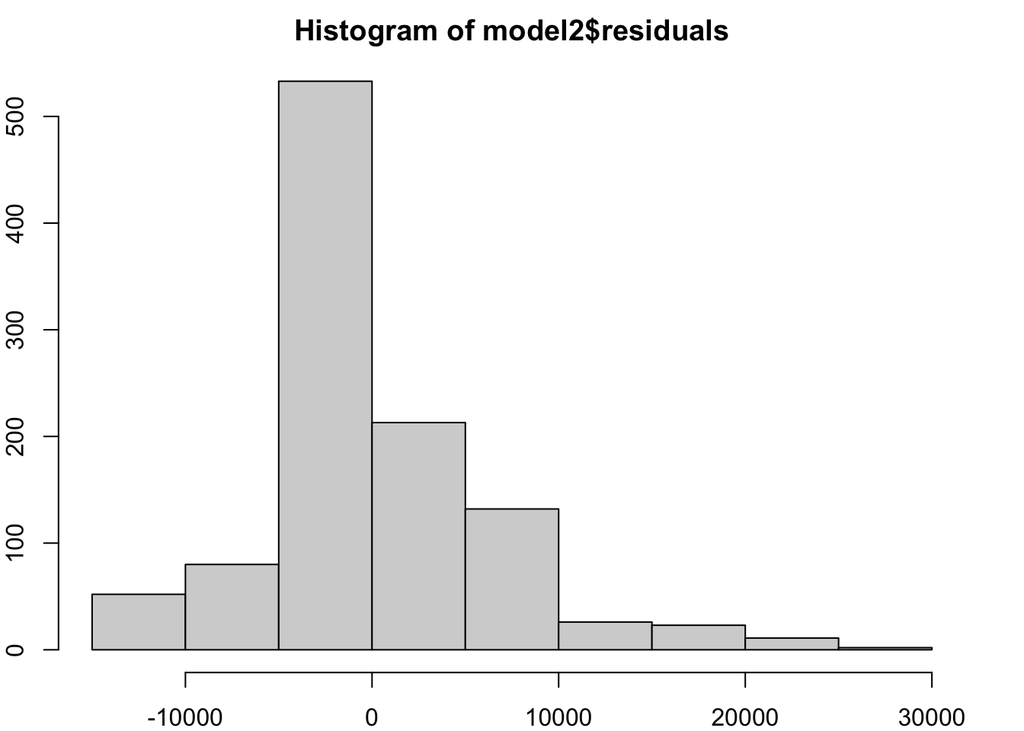

```r
par(mar=c(2,2,2,2))
hist(model2$residuals)
```

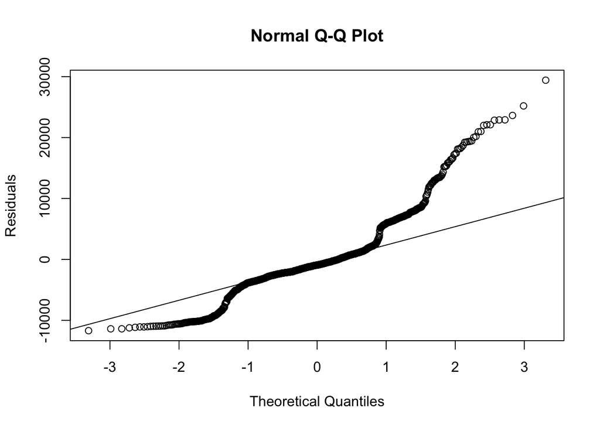

```r
qqnorm(model2$residuals,ylab = "Residuals")
qqline(model2$residuals)
```

```r
pred <- model2 %>%
  predict(test)
R2 <- R2(pred,test$charges)
R2
```

```
## [1] 0.7127615
```

The R squared value may be seemingly lower than the one from the first model, but note that this model contains the train and test set and only 4/5 th of the dataset is used in training the model. Mover, this is fairly closer to the r squared achieved above (0.75) and considering this is built with only statistically significant attributes, the model will generally yeild better results for untrained data, i.e, new data. Hence, model2 can be considered for future predictions and hence it is the better model.